# Phage Proteome Analysis

We have proteomics data from three different strains of T7 after 1, 5, and 9 minutes of infection in E. coli. Each time point has 4 replicates. There is an additional replicate done year earlier than the other 4 which is not included in the analyses.

**evolved**: evolved phage with codon-modified gene 10

**recoded**: initial codon-modified gene 10 phage

**wildtype**: wild-type phage

**Normalization:** Data are normalized by total protein area (T7 and E. coli) for each sample *after* computing areas.

### Major capsid protein levels are depressed in recoded and evolved strains

## Phage proteins immediately downstream of gp10 are also depressed

### Peak areas

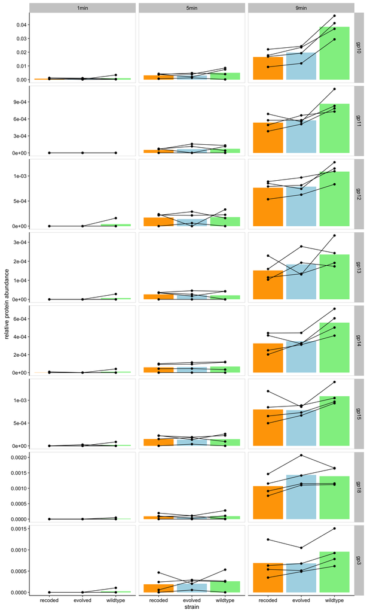

The difference in abundance between the wildtype and attenuated strains for the above proteins are all significant (see the table of p-values at the bottom of the document).

## In aggregate, phage protein levels (not including major capsid) look about the same across strains

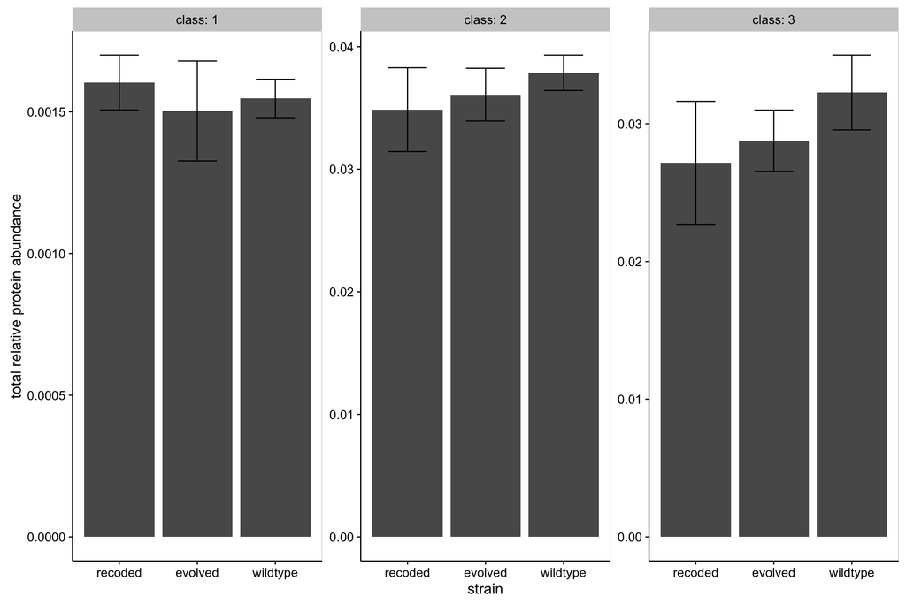

### Class 3 protein levels (not including capsid) look roughly the same

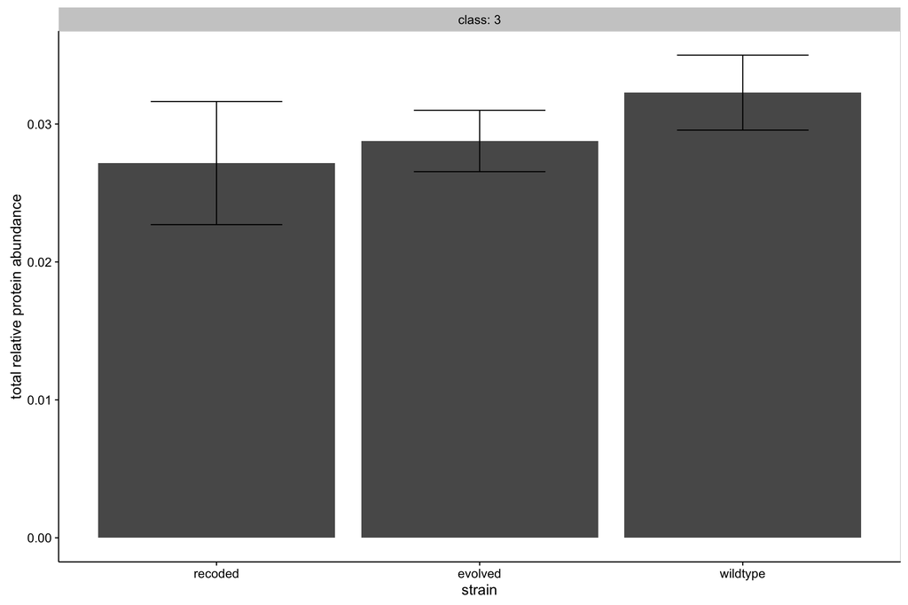

### Classes 1 and 2 also look roughly the same across all three strains

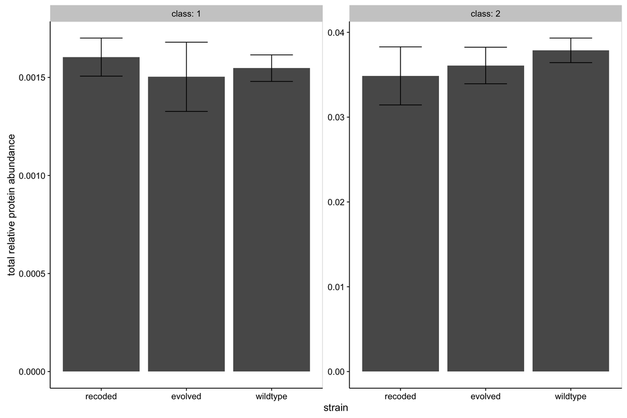

## Which proteins are significantly different across strains?

Looking at the class 3 genes, there seem to be systematic batch effects between biological replicates. For example, replicate 4 might have lower abundances for a given protein in all three strains. I’ve attempted to model this with a mixed effects model:

```r
library(lmerTest)

# Let's just look at the 9min mark without the evolved strain or gp10A
all_data2 <- filter(all_data, tabasco_id != "gp10", time == "9min", strain != "evol", class == 3)

# Build a model with protein abundance as the response, strain and protein as fixed, and biological replicate as random
mod <- lmer(area_norm ~ strain + tabasco_id + (1 | b_rep), data = all_data2)

anova(mod)
```

```
## Analysis of Variance Table of type III  with  Satterthwaite
## approximation for degrees of freedom
##                Sum Sq    Mean Sq NumDF DenDF F.value  Pr(>F)
## strain     0.00000249 2.4860e-06     1   150   5.327 0.02236 *
## tabasco_id 0.00088284 4.4142e-05    20   150  94.581 < 2e-16 ***
## ---
## Signif. codes:  0 '***' 0.001 '**' 0.01 '*' 0.05 '.' 0.1 ' ' 1
```

| Proteins | tabasco_id | class | p.value | estimate | p.value_adj |
| --- | --- | --- | --- | --- | --- |
| NP_041972.1 | gp3 | 2 | 0.0001414 | 0.0002673 | 0.0060789 |
| NP_041998.1 | gp10 | 3 | 0.0005144 | 0.0220633 | 0.0110602 |
| NP_042001.1 | gp13 | 3 | 0.0018144 | 0.0000838 | 0.0260065 |
| NP_042000.1 | gp12 | 3 | 0.0058970 | 0.0003209 | 0.0507145 |
| NP_042002.1 | gp14 | 3 | 0.0055731 | 0.0002316 | 0.0507145 |
| NP_041999.1 | gp11 | 3 | 0.0074103 | 0.0003338 | 0.0531070 |
| NP_042003.1 | gp15 | 3 | 0.0143161 | 0.0002897 | 0.0878116 |
| NP_042007.1 | gp18 | 3 | 0.0163370 | 0.0003231 | 0.0878116 |

# When do genes get turned on in different strains?

If there are differences between class 3 protein abundances in the wildtype and attenuated strains, then presumably we should also see a difference in the *changes* in protein abundance in these strains between 5 and 9 minutes. The following table compares the *differences* between protein abundances going from 5 min to 9 min in each strain. I find that 6 proteins fall below the 0.1 FDR-corrected p-value cutoff.

| b_rep | class | tabasco_id | Proteins | fold_change_wt |
| --- | --- | --- | --- | --- |
| 5 | 3 | gp10 | NP_041998.1 | 0.0391108 |
| 2 | 3 | gp10 | NP_041998.1 | 0.0371216 |
| 4 | 3 | gp10 | NP_041998.1 | 0.0292050 |
| 3 | 3 | gp10 | NP_041998.1 | 0.0284964 |
| 4 | 2 | gp2.5 | NP_041970.1 | 0.0123069 |
| 2 | 2 | gp2.5 | NP_041970.1 | 0.0104152 |
| 4 | 3 | gp9 | NP_041996.1 | 0.0103351 |
| 3 | 3 | gp9 | NP_041996.1 | 0.0097017 |
| 5 | 3 | gp9 | NP_041996.1 | 0.0094340 |
| 2 | 3 | gp9 | NP_041996.1 | 0.0086957 |
| 3 | 2 | gp2.5 | NP_041970.1 | 0.0078102 |
| 4 | 2 | gp3.5 | NP_041973.1 | 0.0062864 |
| 5 | 3 | gp7.3 | NP_041993.1 | 0.0060960 |
| 5 | 2 | gp2.5 | NP_041970.1 | 0.0055400 |
| 3 | 3 | gp7.3 | NP_041993.1 | 0.0050512 |
| 3 | 2 | gp3.5 | NP_041973.1 | 0.0032029 |
| 4 | 3 | gp8 | NP_041995.1 | 0.0031807 |
| 5 | 2 | gp3.5 | NP_041973.1 | 0.0031071 |
| 2 | 3 | gp8 | NP_041995.1 | 0.0029380 |
| 4 | 2 | gp1.3 | NP_041963.1 | 0.0029107 |
| 4 | 3 | gp7.3 | NP_041993.1 | 0.0027390 |
| 3 | 3 | gp8 | NP_041995.1 | 0.0026779 |
| 2 | 2 | gp3.5 | NP_041973.1 | 0.0026422 |
| 5 | 3 | gp8 | NP_041995.1 | 0.0025712 |
| 4 | 2 | gp4.5 | NP_041980.1 | 0.0025709 |
| 5 | 3 | gp17 | NP_042005.1 | 0.0024767 |
| 2 | 3 | gp7.3 | NP_041993.1 | 0.0023696 |
| 4 | 2 | gp4.7 | NP_041981.1 | 0.0023512 |
| 4 | 3 | gp17 | NP_042005.1 | 0.0021825 |
| 2 | 3 | gp17 | NP_042005.1 | 0.0021500 |

[output cut: 158 more lines]

| Proteins | tabasco_id | class | p.value | estimate | p.value_adj |
| --- | --- | --- | --- | --- | --- |
| NP_041998.1 | gp10 | 3 | 0.0017219 | 0.0201512 | 0.0246810 |
| NP_041970.1 | gp2.5 | 2 | 0.5083873 | 0.0015410 | 0.7042739 |
| NP_041996.1 | gp9 | 3 | 0.3911576 | 0.0011842 | 0.6184556 |
| NP_041973.1 | gp3.5 | 2 | 0.2044274 | 0.0011832 | 0.4185894 |
| NP_041995.1 | gp8 | 3 | 0.1062230 | 0.0007318 | 0.3244359 |
| NP_041967.1 | gp1.7 | 2 | 0.0235670 | 0.0005036 | 0.1254811 |
| NP_042005.1 | gp17 | 3 | 0.1012610 | 0.0004708 | 0.3244359 |
| NP_041993.1 | gp7.3 | 3 | 0.2486658 | 0.0004342 | 0.4860286 |
| NP_041988.1 | gp6 | 2 | 0.0783471 | 0.0003856 | 0.2807438 |
| NP_041963.1 | gp1.3 | 2 | 0.1131753 | 0.0003769 | 0.3244359 |
| NP_042007.1 | gp18 | 3 | 0.0262635 | 0.0003185 | 0.1254811 |
| NP_041999.1 | gp11 | 3 | 0.0094795 | 0.0003138 | 0.0815236 |
| NP_042000.1 | gp12 | 3 | 0.0005395 | 0.0003100 | 0.0231993 |
| NP_042003.1 | gp15 | 3 | 0.0214476 | 0.0002934 | 0.1254811 |
| NP_041990.1 | gp6.5 | 3 | 0.1328645 | 0.0002677 | 0.3570733 |
| NP_042002.1 | gp14 | 3 | 0.0060721 | 0.0002228 | 0.0652753 |
| NP_042004.1 | gp16 | 3 | 0.0457929 | 0.0002213 | 0.1790087 |
| NP_041991.1 | gp6.7 | 3 | 0.0342548 | 0.0002153 | 0.1472958 |
| NP_041972.1 | gp3 | 2 | 0.0122217 | 0.0001954 | 0.0875889 |
| NP_041966.1 | gp1.6 | 2 | 0.5241108 | 0.0001776 | 0.7042739 |
| NP_041987.1 | gp5.9 | 2 | 0.1940527 | 0.0001704 | 0.4172133 |
| NP_041971.1 | gp2.8 | 2 | 0.4075128 | 0.0001292 | 0.6184556 |
| NP_041974.1 | gp3.8 | 2 | 0.3120765 | 0.0001043 | 0.5591370 |
| NP_041981.1 | gp4.7 | 2 | 0.4323057 | 0.0000954 | 0.6196381 |
| NP_042001.1 | gp13 | 3 | 0.0011028 | 0.0000888 | 0.0237110 |
| NP_041992.1 | gp7 | 3 | 0.3447749 | 0.0000799 | 0.5930128 |
| NP_041960.1 | gp1 | 1 | 0.7432891 | 0.0000684 | 0.8638225 |
| NP_042008.1 | gp18.5 | 3 | 0.1550864 | 0.0000545 | 0.3922774 |
| NP_041962.1 | gp1.2 | 2 | 0.2745132 | 0.0000483 | 0.5132202 |
| NP_041959.1 | gp0.7 | 1 | 0.7993198 | 0.0000389 | 0.9044935 |
| NP_041979.1 | gp4.3 | 2 | 0.6832218 | 0.0000217 | 0.8510958 |
| NP_041978.1 | gp4.2 | 2 | 0.1817427 | 0.0000203 | 0.4172133 |
| NP_041982.1 | gp5 | 2 | 0.9509578 | 0.0000125 | 0.9973460 |
| NP_041980.1 | gp4.5 | 2 | 0.9985649 | 0.0000004 | 0.9985649 |
| NP_041968.1 | gp1.8 | 2 | 0.9923665 | 0.0000003 | 0.9985649 |
| NP_041955.1 | gp0.4 | 1 | NaN | 0.0000000 | NaN |
| NP_041965.1 | gp1.5 | 2 | NaN | 0.0000000 | NaN |
| NP_041997.1 | gp10B | 3 | NaN | 0.0000000 | NaN |
| NP_042006.1 | gp17.5 | 3 | NaN | 0.0000000 | NaN |
| NP_041954.1 | gp0.3 | 1 | 0.3910022 | -0.0000016 | 0.6184556 |
| NP_042013.1 | gp19.5 | 3 | 0.8966897 | -0.0000033 | 0.9639415 |
| NP_041983.1 | gp5.3 | 2 | 0.6927524 | -0.0000076 | 0.8510958 |
| NP_042009.1 | gp18.7 | 3 | 0.1873297 | -0.0000080 | 0.4172133 |
| NP_041969.1 | gp2 | 2 | 0.5972253 | -0.0000185 | 0.7782026 |
| NP_042010.1 | gp19 | 3 | 0.7161986 | -0.0000283 | 0.8554594 |
| NP_041994.1 | gp7.7 | 3 | 0.8530991 | -0.0000382 | 0.9405965 |
| NP_041975.1 | gp4A | 2 | 0.4170979 | -0.0001385 | 0.6184556 |

| Proteins | tabasco_id | class | p.value | estimate | p.value_adj |
| --- | --- | --- | --- | --- | --- |
| NP_042000.1 | gp12 | 3 | 0.0005395 | 0.0003100 | 0.0231993 |
| NP_042001.1 | gp13 | 3 | 0.0011028 | 0.0000888 | 0.0237110 |
| NP_041998.1 | gp10 | 3 | 0.0017219 | 0.0201512 | 0.0246810 |
| NP_042002.1 | gp14 | 3 | 0.0060721 | 0.0002228 | 0.0652753 |
| NP_041999.1 | gp11 | 3 | 0.0094795 | 0.0003138 | 0.0815236 |
| NP_041972.1 | gp3 | 2 | 0.0122217 | 0.0001954 | 0.0875889 |
| NP_041967.1 | gp1.7 | 2 | 0.0235670 | 0.0005036 | 0.1254811 |
| NP_042007.1 | gp18 | 3 | 0.0262635 | 0.0003185 | 0.1254811 |
| NP_042003.1 | gp15 | 3 | 0.0214476 | 0.0002934 | 0.1254811 |
| NP_041991.1 | gp6.7 | 3 | 0.0342548 | 0.0002153 | 0.1472958 |
| NP_042004.1 | gp16 | 3 | 0.0457929 | 0.0002213 | 0.1790087 |
| NP_041988.1 | gp6 | 2 | 0.0783471 | 0.0003856 | 0.2807438 |
| NP_041995.1 | gp8 | 3 | 0.1062230 | 0.0007318 | 0.3244359 |
| NP_042005.1 | gp17 | 3 | 0.1012610 | 0.0004708 | 0.3244359 |
| NP_041963.1 | gp1.3 | 2 | 0.1131753 | 0.0003769 | 0.3244359 |
| NP_041990.1 | gp6.5 | 3 | 0.1328645 | 0.0002677 | 0.3570733 |
| NP_042008.1 | gp18.5 | 3 | 0.1550864 | 0.0000545 | 0.3922774 |
| NP_041987.1 | gp5.9 | 2 | 0.1940527 | 0.0001704 | 0.4172133 |
| NP_041978.1 | gp4.2 | 2 | 0.1817427 | 0.0000203 | 0.4172133 |
| NP_042009.1 | gp18.7 | 3 | 0.1873297 | -0.0000080 | 0.4172133 |
| NP_041973.1 | gp3.5 | 2 | 0.2044274 | 0.0011832 | 0.4185894 |
| NP_041993.1 | gp7.3 | 3 | 0.2486658 | 0.0004342 | 0.4860286 |
| NP_041962.1 | gp1.2 | 2 | 0.2745132 | 0.0000483 | 0.5132202 |
| NP_041974.1 | gp3.8 | 2 | 0.3120765 | 0.0001043 | 0.5591370 |
| NP_041992.1 | gp7 | 3 | 0.3447749 | 0.0000799 | 0.5930128 |
| NP_041996.1 | gp9 | 3 | 0.3911576 | 0.0011842 | 0.6184556 |
| NP_041971.1 | gp2.8 | 2 | 0.4075128 | 0.0001292 | 0.6184556 |
| NP_041954.1 | gp0.3 | 1 | 0.3910022 | -0.0000016 | 0.6184556 |
| NP_041975.1 | gp4A | 2 | 0.4170979 | -0.0001385 | 0.6184556 |
| NP_041981.1 | gp4.7 | 2 | 0.4323057 | 0.0000954 | 0.6196381 |
| NP_041970.1 | gp2.5 | 2 | 0.5083873 | 0.0015410 | 0.7042739 |
| NP_041966.1 | gp1.6 | 2 | 0.5241108 | 0.0001776 | 0.7042739 |
| NP_041969.1 | gp2 | 2 | 0.5972253 | -0.0000185 | 0.7782026 |
| NP_041979.1 | gp4.3 | 2 | 0.6832218 | 0.0000217 | 0.8510958 |
| NP_041983.1 | gp5.3 | 2 | 0.6927524 | -0.0000076 | 0.8510958 |
| NP_042010.1 | gp19 | 3 | 0.7161986 | -0.0000283 | 0.8554594 |
| NP_041960.1 | gp1 | 1 | 0.7432891 | 0.0000684 | 0.8638225 |
| NP_041959.1 | gp0.7 | 1 | 0.7993198 | 0.0000389 | 0.9044935 |
| NP_041994.1 | gp7.7 | 3 | 0.8530991 | -0.0000382 | 0.9405965 |
| NP_042013.1 | gp19.5 | 3 | 0.8966897 | -0.0000033 | 0.9639415 |
| NP_041982.1 | gp5 | 2 | 0.9509578 | 0.0000125 | 0.9973460 |
| NP_041980.1 | gp4.5 | 2 | 0.9985649 | 0.0000004 | 0.9985649 |
| NP_041968.1 | gp1.8 | 2 | 0.9923665 | 0.0000003 | 0.9985649 |
| NP_041955.1 | gp0.4 | 1 | NaN | 0.0000000 | NaN |
| NP_041965.1 | gp1.5 | 2 | NaN | 0.0000000 | NaN |
| NP_041997.1 | gp10B | 3 | NaN | 0.0000000 | NaN |
| NP_042006.1 | gp17.5 | 3 | NaN | 0.0000000 | NaN |

Next, I looked at similar changes in protein abundance between 1 minute and 5 minutes. No significant changes were detected, even class 1 and class 2 proteins. The quantity of proteins at these times are probably just too low and too noisy to detect any trends.

| Proteins | tabasco_id | class | p.value | estimate | p.value_adj |
| --- | --- | --- | --- | --- | --- |
| NP_041959.1 | gp0.7 | 1 | 0.5013537 | -0.0001460 | 0.8455780 |
| NP_041960.1 | gp1 | 1 | 0.4579499 | -0.0003581 | 0.8455780 |
| NP_041962.1 | gp1.2 | 2 | 0.1685856 | -0.0000773 | 0.8455780 |
| NP_041963.1 | gp1.3 | 2 | 0.2984306 | -0.0003470 | 0.8455780 |
| NP_041966.1 | gp1.6 | 2 | 0.5087267 | -0.0001961 | 0.8455780 |
| NP_041967.1 | gp1.7 | 2 | 0.2582290 | -0.0003447 | 0.8455780 |
| NP_041968.1 | gp1.8 | 2 | 0.2418953 | -0.0000571 | 0.8455780 |
| NP_041969.1 | gp2 | 2 | 0.5025834 | -0.0000103 | 0.8455780 |
| NP_041970.1 | gp2.5 | 2 | 0.0823034 | -0.0018877 | 0.8455780 |
| NP_041971.1 | gp2.8 | 2 | 0.1430072 | -0.0000819 | 0.8455780 |
| NP_041972.1 | gp3 | 2 | 0.5187093 | 0.0000454 | 0.8455780 |
| NP_041973.1 | gp3.5 | 2 | 0.2453069 | -0.0003027 | 0.8455780 |
| NP_041978.1 | gp4.2 | 2 | 0.3910022 | -0.0000103 | 0.8455780 |
| NP_041981.1 | gp4.7 | 2 | 0.3629953 | -0.0002881 | 0.8455780 |
| NP_041975.1 | gp4A | 2 | 0.5284863 | 0.0001128 | 0.8455780 |
| NP_041982.1 | gp5 | 2 | 0.3807881 | -0.0001585 | 0.8455780 |
| NP_041988.1 | gp6 | 2 | 0.3446377 | -0.0001678 | 0.8455780 |
| NP_041998.1 | gp10 | 3 | 0.4607419 | 0.0015480 | 0.8455780 |
| NP_041999.1 | gp11 | 3 | 0.4248947 | 0.0000200 | 0.8455780 |
| NP_042001.1 | gp13 | 3 | 0.3644902 | -0.0000120 | 0.8455780 |
| NP_042003.1 | gp15 | 3 | 0.4326902 | -0.0000253 | 0.8455780 |
| NP_042004.1 | gp16 | 3 | 0.4102110 | -0.0000454 | 0.8455780 |
| NP_042010.1 | gp19 | 3 | 0.4194679 | -0.0000148 | 0.8455780 |
| NP_041991.1 | gp6.7 | 3 | 0.1829528 | -0.0000386 | 0.8455780 |
| NP_041995.1 | gp8 | 3 | 0.3671818 | -0.0001252 | 0.8455780 |
| NP_042008.1 | gp18.5 | 3 | 0.5724439 | -0.0000232 | 0.8480651 |
| NP_041993.1 | gp7.3 | 3 | 0.5573963 | -0.0001198 | 0.8480651 |
| NP_042000.1 | gp12 | 3 | 0.6239058 | -0.0000291 | 0.8605598 |
| NP_041992.1 | gp7 | 3 | 0.6036123 | -0.0000127 | 0.8605598 |
| NP_041980.1 | gp4.5 | 2 | 0.6469201 | -0.0001439 | 0.8625601 |
| NP_041974.1 | gp3.8 | 2 | 0.7475285 | -0.0000186 | 0.9344107 |
| NP_041996.1 | gp9 | 3 | 0.7415283 | -0.0001537 | 0.9344107 |
| NP_041990.1 | gp6.5 | 3 | 0.7849182 | -0.0000497 | 0.9514160 |
| NP_041979.1 | gp4.3 | 2 | 0.8752002 | -0.0000239 | 0.9582135 |
| NP_041983.1 | gp5.3 | 2 | 0.9252503 | -0.0000012 | 0.9582135 |
| NP_041987.1 | gp5.9 | 2 | 0.8614220 | -0.0000183 | 0.9582135 |
| NP_042005.1 | gp17 | 3 | 0.9342581 | -0.0000067 | 0.9582135 |
| NP_042007.1 | gp18 | 3 | 0.8398728 | -0.0000077 | 0.9582135 |
| NP_041994.1 | gp7.7 | 3 | 0.8887870 | -0.0000075 | 0.9582135 |
| NP_042002.1 | gp14 | 3 | 0.9595869 | 0.0000008 | 0.9595869 |
| NP_041954.1 | gp0.3 | 1 | NaN | 0.0000000 | NaN |
| NP_041955.1 | gp0.4 | 1 | NaN | 0.0000000 | NaN |
| NP_041965.1 | gp1.5 | 2 | NaN | 0.0000000 | NaN |
| NP_041997.1 | gp10B | 3 | NaN | 0.0000000 | NaN |
| NP_042006.1 | gp17.5 | 3 | NaN | 0.0000000 | NaN |
| NP_042009.1 | gp18.7 | 3 | NaN | 0.0000000 | NaN |
| NP_042013.1 | gp19.5 | 3 | NaN | 0.0000000 | NaN |

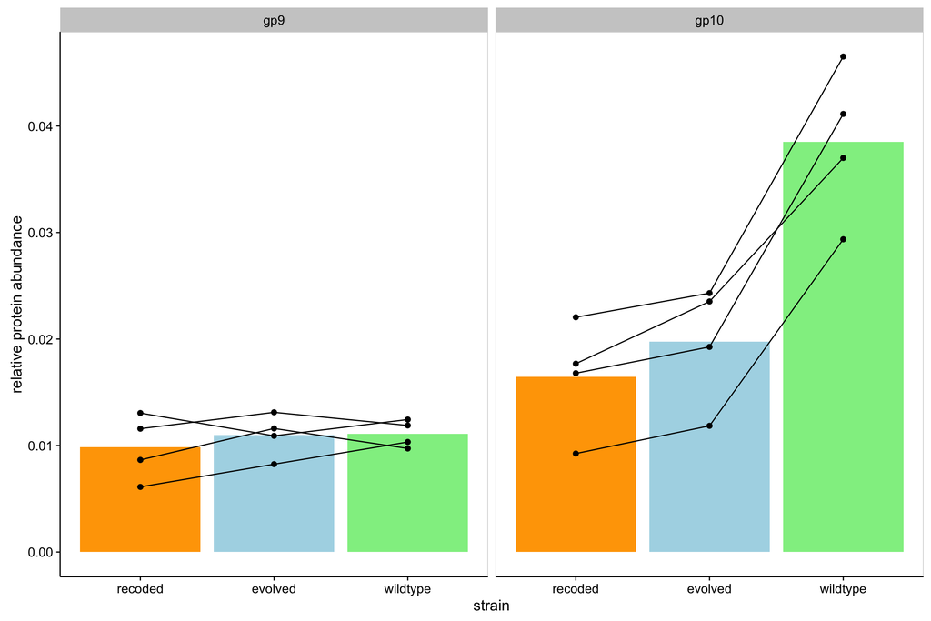

## Exploring protein ratios

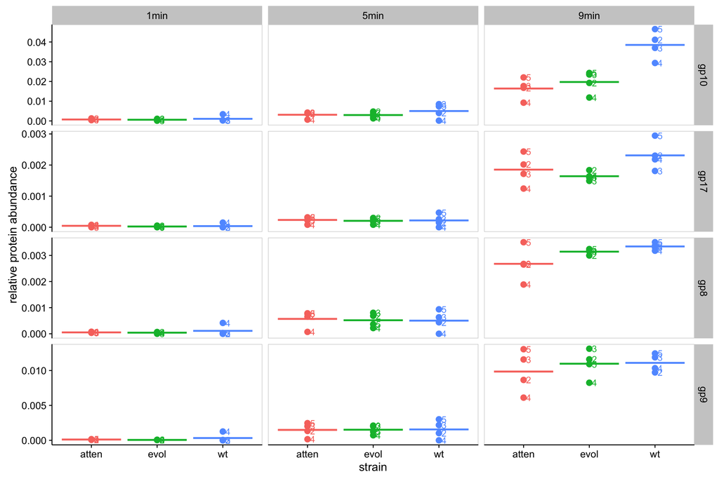

|  | atten | evol | wt | true_ratio |
| --- | --- | --- | --- | --- |
| gp10A:gp9 | 1.7 | 1.8 | 3.5 | 3.3 |
| gp10A:gp17 | 8.9 | 12.0 | 16.7 | 23.1 |
| gp10A:gp8 | 6.1 | 6.3 | 11.5 | 34.6 |
| gp9:gp17 | 5.3 | 6.7 | 4.8 | 6.9 |
| gp9:gp8 | 3.7 | 3.5 | 3.3 | 10.4 |